# Problem Set 5: Logistic Regression, SVM, Classification

## Introduction

This project revolves around classiffcation, k-NN, logistic regression, support vector machines, & ROC curves.

## Wisconsin Breast Cancer Dataset

This project works with Wisconsin Breast Cancer Dataset (WBCD), available at UCI Machine Learning Repository. You can download it from the internet but rather use the files wdbc.csv.bz2 and wdbc_doc.txt which has added variable names to the data. The first file is the csv with variable names, the second one a brief description of the data.

The data includes diagnosis of the tumor with M cancer (malignant) and B no cancer (benign), and 10 features, describing physical properties of cell nuclei from biopsy samples. Each feature is represented three times, once for mean, once for standard error, and once for the worst values.

## 1. Explore the Data

As the first step, explore the data.

1. Load the data. You may drop id or just ignore it in the rest of your analysis.
2. Create a summary table where you show means, ranges, and number of missings for each variable. In addition, add (Pearson) correlation between the diagnosis and the corresponding feature.
3. Graphical exploration for the relationships between features and the diagnosis.

```python
import numpy as np
import pandas as pd
import matplotlib.pyplot as plt
import seaborn as sns

df = pd.read_csv("wdbc.csv")
df = df.drop(['id'], axis=1)
df.head()
```

|  | diagnosis | radius.mean | texture.mean | perimeter.mean | area.mean | smoothness.mean | compactness.mean | concavity.mean | concpoints.mean | symmetry.mean | ... | radius.worst | texture.worst | perimeter.worst | area.worst | smoothness.worst | compactness.worst | concavity.worst | concpoints.worst | symmetry.worst | fracdim.worst |
| --- | --- | --- | --- | --- | --- | --- | --- | --- | --- | --- | --- | --- | --- | --- | --- | --- | --- | --- | --- | --- | --- |
| 0 | M | 17.99 | 10.38 | 122.80 | 1001.0 | 0.11840 | 0.27760 | 0.3001 | 0.14710 | 0.2419 | ... | 25.38 | 17.33 | 184.60 | 2019.0 | 0.1622 | 0.6656 | 0.7119 | 0.2654 | 0.4601 | 0.11890 |
| 1 | M | 20.57 | 17.77 | 132.90 | 1326.0 | 0.08474 | 0.07864 | 0.0869 | 0.07017 | 0.1812 | ... | 24.99 | 23.41 | 158.80 | 1956.0 | 0.1238 | 0.1866 | 0.2416 | 0.1860 | 0.2750 | 0.08902 |
| 2 | M | 19.69 | 21.25 | 130.00 | 1203.0 | 0.10960 | 0.15990 | 0.1974 | 0.12790 | 0.2069 | ... | 23.57 | 25.53 | 152.50 | 1709.0 | 0.1444 | 0.4245 | 0.4504 | 0.2430 | 0.3613 | 0.08758 |
| 3 | M | 11.42 | 20.38 | 77.58 | 386.1 | 0.14250 | 0.28390 | 0.2414 | 0.10520 | 0.2597 | ... | 14.91 | 26.50 | 98.87 | 567.7 | 0.2098 | 0.8663 | 0.6869 | 0.2575 | 0.6638 | 0.17300 |
| 4 | M | 20.29 | 14.34 | 135.10 | 1297.0 | 0.10030 | 0.13280 | 0.1980 | 0.10430 | 0.1809 | ... | 22.54 | 16.67 | 152.20 | 1575.0 | 0.1374 | 0.2050 | 0.4000 | 0.1625 | 0.2364 | 0.07678 |

5 rows × 31 columns

```python
df['diagnosis'] = df['diagnosis'].map({'M': 1, 'B': 0})
```

```python
# Get NAs for each variable
na = df.isnull().sum()
na = pd.DataFrame(data=na)
```

```python
# Get other summary stats
summary = df.describe().transpose()
summary.columns = ['count','mean','std','min','25%','median','75%','max']
summary = summary[['count','mean','std','min','median','max']]
```

```python
# Get Pearson correlation
p_corr = df.corr(method="pearson")
p_corr = p_corr["diagnosis"]
p_corr.columns = ['Correlation']
```

```python
# Merge tables together
summary_stats = pd.concat([summary, na, p_corr], axis=1)
summary_stats.columns = ['Count','Mean','Std','Min','Median','Max', 'NAs', 'Correlation']
summary_stats
```

|  | Count | Mean | Std | Min | Median | Max | NAs | Correlation |
| --- | --- | --- | --- | --- | --- | --- | --- | --- |
| diagnosis | 569.0 | 0.372583 | 0.483918 | 0.000000 | 0.000000 | 1.00000 | 0 | 1.000000 |
| radius.mean | 569.0 | 14.127292 | 3.524049 | 6.981000 | 13.370000 | 28.11000 | 0 | 0.730029 |
| texture.mean | 569.0 | 19.289649 | 4.301036 | 9.710000 | 18.840000 | 39.28000 | 0 | 0.415185 |
| perimeter.mean | 569.0 | 91.969033 | 24.298981 | 43.790000 | 86.240000 | 188.50000 | 0 | 0.742636 |
| area.mean | 569.0 | 654.889104 | 351.914129 | 143.500000 | 551.100000 | 2501.00000 | 0 | 0.708984 |
| smoothness.mean | 569.0 | 0.096360 | 0.014064 | 0.052630 | 0.095870 | 0.16340 | 0 | 0.358560 |
| compactness.mean | 569.0 | 0.104341 | 0.052813 | 0.019380 | 0.092630 | 0.34540 | 0 | 0.596534 |
| concavity.mean | 569.0 | 0.088799 | 0.079720 | 0.000000 | 0.061540 | 0.42680 | 0 | 0.696360 |
| concpoints.mean | 569.0 | 0.048919 | 0.038803 | 0.000000 | 0.033500 | 0.20120 | 0 | 0.776614 |
| symmetry.mean | 569.0 | 0.181162 | 0.027414 | 0.106000 | 0.179200 | 0.30400 | 0 | 0.330499 |
| fracdim.mean | 569.0 | 0.062798 | 0.007060 | 0.049960 | 0.061540 | 0.09744 | 0 | -0.012838 |
| radius.se | 569.0 | 0.405172 | 0.277313 | 0.111500 | 0.324200 | 2.87300 | 0 | 0.567134 |
| texture.se | 569.0 | 1.216853 | 0.551648 | 0.360200 | 1.108000 | 4.88500 | 0 | -0.008303 |
| perimeter.se | 569.0 | 2.866059 | 2.021855 | 0.757000 | 2.287000 | 21.98000 | 0 | 0.556141 |
| area.se | 569.0 | 40.337079 | 45.491006 | 6.802000 | 24.530000 | 542.20000 | 0 | 0.548236 |
| smoothness.se | 569.0 | 0.007041 | 0.003003 | 0.001713 | 0.006380 | 0.03113 | 0 | -0.067016 |
| compactness.se | 569.0 | 0.025478 | 0.017908 | 0.002252 | 0.020450 | 0.13540 | 0 | 0.292999 |
| concavity.se | 569.0 | 0.031894 | 0.030186 | 0.000000 | 0.025890 | 0.39600 | 0 | 0.253730 |
| concpoints.se | 569.0 | 0.011796 | 0.006170 | 0.000000 | 0.010930 | 0.05279 | 0 | 0.408042 |
| symmetry.se | 569.0 | 0.020542 | 0.008266 | 0.007882 | 0.018730 | 0.07895 | 0 | -0.006522 |
| fracdim.se | 569.0 | 0.003795 | 0.002646 | 0.000895 | 0.003187 | 0.02984 | 0 | 0.077972 |
| radius.worst | 569.0 | 16.269190 | 4.833242 | 7.930000 | 14.970000 | 36.04000 | 0 | 0.776454 |
| texture.worst | 569.0 | 25.677223 | 6.146258 | 12.020000 | 25.410000 | 49.54000 | 0 | 0.456903 |
| perimeter.worst | 569.0 | 107.261213 | 33.602542 | 50.410000 | 97.660000 | 251.20000 | 0 | 0.782914 |
| area.worst | 569.0 | 880.583128 | 569.356993 | 185.200000 | 686.500000 | 4254.00000 | 0 | 0.733825 |
| smoothness.worst | 569.0 | 0.132369 | 0.022832 | 0.071170 | 0.131300 | 0.22260 | 0 | 0.421465 |
| compactness.worst | 569.0 | 0.254265 | 0.157336 | 0.027290 | 0.211900 | 1.05800 | 0 | 0.590998 |
| concavity.worst | 569.0 | 0.272188 | 0.208624 | 0.000000 | 0.226700 | 1.25200 | 0 | 0.659610 |
| concpoints.worst | 569.0 | 0.114606 | 0.065732 | 0.000000 | 0.099930 | 0.29100 | 0 | 0.793566 |
| symmetry.worst | 569.0 | 0.290076 | 0.061867 | 0.156500 | 0.282200 | 0.66380 | 0 | 0.416294 |
| fracdim.worst | 569.0 | 0.083946 | 0.018061 | 0.055040 | 0.080040 | 0.20750 | 0 | 0.323872 |

First, let's explore the relationship between *area* and *texture*. Both are expected to have a malignant diagnosis as both variables increase, and this is supported in the scatterplot below. Texture, however, doesn't seem to have a strong correlation to tell between benign and malignant respective to area.

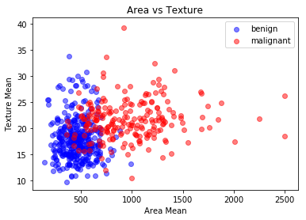

```python
b = df[df['diagnosis'] == 'B']
m = df[df['diagnosis'] == 'M']

plt.scatter(b['area.mean'], b['texture.mean'], label = 'benign', c='blue', alpha=0.5)
plt.scatter(m['area.mean'], m['texture.mean'], label = 'malignant', c='red', alpha=0.5)
plt.xlabel("Area Mean")
plt.ylabel("Texture Mean")
plt.title("Area vs Texture")
plt.legend(['benign', 'malignant'])
plt.show()
```

Next, I wanted to see if there was any difference when comparing the **worst** of the area and texture measures I had looked into above. I noticed that the area of points in the scatterplot for *benign* is narrower in respect to *malignant* for the area variable. The worst area for malignant is over 4000!

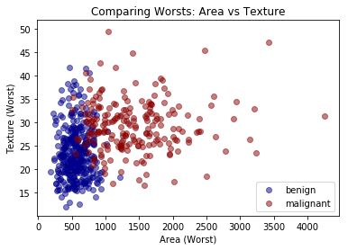

```python
plt.scatter(b['area.worst'], b['texture.worst'], label = 'benign', c='darkblue', alpha=0.5)
plt.scatter(m['area.worst'], m['texture.worst'], label = 'malignant', c='darkred', alpha=0.5)
plt.xlabel("Area (Worst)")
plt.ylabel("Texture (Worst)")
plt.title("Comparing Worsts: Area vs Texture")
plt.legend(['benign', 'malignant'])
plt.show()
```

I also was curious to see how *concavity* and *symmetry* play a role in the diagnosis of cancer. We can see that the range for concavity that is diagnosed as malignant goes a long way. Symmetry doesn't seem to have a strong correlation to tell between benign and malignant, especially not as much as other variables such as concavity or area.

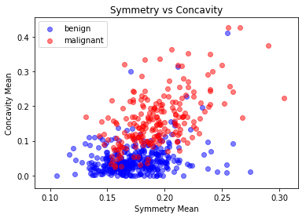

```python
plt.scatter(b['symmetry.mean'], b['concavity.mean'], label = 'benign', c='blue', alpha=0.5)
plt.scatter(m['symmetry.mean'], m['concavity.mean'], label = 'malignant', c='red', alpha=0.5)
plt.xlabel("Symmetry Mean")
plt.ylabel("Concavity Mean")
plt.title("Symmetry vs Concavity")
plt.legend(['benign', 'malignant'])
plt.show()
```

Now that we've seen a preview of these variables, let's see how they pair up with each other in a scatterplot matrix!

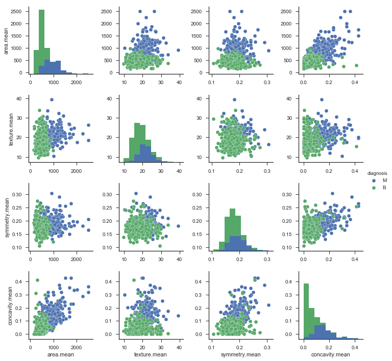

```python
sns.set(style="ticks")
matrix = df[['area.mean', 'texture.mean', 'symmetry.mean', 'concavity.mean', 'diagnosis']]
sns.pairplot(matrix, hue="diagnosis")
plt.show()
```

## 2. Decision Boundary

Now let's plot the decision boundary when using logistic regression. Let's also play a little with feature engineering.

There are two broad strategies to plot this: In any case, we have first to estimate (train) your model. Thereafter we have to predict the classes (cancer/no cancer here) on a regular dense grid that covers the parameter space. Afterwards, we can either plot our predicted values with a certain color code, or alternatively, set predicted M to 1 and predicted B to 0, and make a contour plot for a single contour at level 0.5. We could also combine these both methods.

We ignore training/testing/overfitting issues for now.

### 2.1 kNN Case

First, let's explore the decision boundary using k-NN.

Pick two features. I recommend to use a few that show relative strong correlation with diagnosis, and that vary widely across the scatterplot (not just highly correlated narrow line).

1: Predict the diagnosis on a grid (say, 100 × 100, or less if this is too slow) that covers the range of the explanatory variables. Use k-NN with k = 3..7 (pick just one value). This gives you 100x100 predicted diagnoses.

Note: if your features are of very different scale, you should either scale these into a roughly equal scale, or use a metric that does this with you. Consult James et al. (2015, p 217).

2: Plot the actual data and the decision boundary on the same plot. Ensure that actual observations and predictions are clearly distinguishable, and that one can easily understand the color code.

```python
from sklearn.preprocessing import StandardScaler
from sklearn.model_selection import train_test_split
from sklearn.neighbors import KNeighborsClassifier

scaler = StandardScaler()
X = scaler.fit_transform(df.loc[:,df.columns != "diagnosis"])
y = df[['diagnosis']].to_numpy()

# Split train test
X_train, X_test, y_train, y_test = train_test_split(X, y, test_size=0.33, random_state=42)
```

```python
# KNN
# Grab texture and concavity - seem to have some correlation
X_all = X_train[:,[1, 6]]
X1 = X_all[:,0]
X2 = X_all[:,1]

Y = y_train.ravel()

m = KNeighborsClassifier(n_neighbors = 5)
m.fit(X_all, Y)
```

```
KNeighborsClassifier(algorithm='auto', leaf_size=30, metric='minkowski',
           metric_params=None, n_jobs=1, n_neighbors=5, p=2,
           weights='uniform')
```

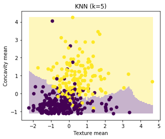

```python
## Now greate the regular grid
ex1 = np.linspace(X1.min(), X1.max(), 100)
ex2 = np.linspace(X2.min(), X2.max(), 100)
xx1, xx2 = np.meshgrid(ex1, ex2) # unlike R-s 'expand.grid', meshgrid creates matrices

g = np.stack((xx1.ravel(), xx2.ravel()), axis=1)
# we create the design matrix by stacking the xx1, xx2 after unraveling those into columns

## predict on the grid
hatY = m.predict(g).reshape(100,100) # imshow wants a matrix, so we reshape the predicted vector into one
plt.imshow(hatY, extent=(X1.min(), X1.max(), X2.min(), X2.max()),
           interpolation='none', origin='lower',alpha=0.3)

plt.scatter(X1, X2, c=Y)
plt.xlabel("Texture mean")
plt.ylabel("Concavity mean")
plt.title("KNN (k=5)")
plt.show()
```

3: How good is kNN in picking up the actual shape? Does it also pick up noise?

kNN does pretty well in picking up the actual shape! Without doing cross-validation, my best judgement is that it also does an alright job picking up some noise that is on the outisde of the bulk mass of the noise in the middle.

### 2.2 Logistic Regression

Now repeat the process above by logistic regression. Pick the same features as what was used for k-NN above.

1: Fit a logistic regression model with these two features.

```python
from sklearn.linear_model import LogisticRegression
m = LogisticRegression().fit(X_all, Y)
```

2: Predict the diagnosis on a similar grid. . .

```python
## Now greate the regular grid
ex1 = np.linspace(X1.min(), X1.max(), 100)
ex2 = np.linspace(X2.min(), X2.max(), 100)
xx1, xx2 = np.meshgrid(ex1, ex2) # unlike R-s 'expand.grid', meshgrid creates matrices

g = np.stack((xx1.ravel(), xx2.ravel()), axis=1)
# we create the design matrix by stacking the xx1, xx2 after unraveling those into columns

## predict on the grid
hatY = m.predict(g).reshape(100,100) # imshow wants a matrix, so we reshape the predicted vector into one
plt.imshow(hatY, extent=(X1.min(), X1.max(), X2.min(), X2.max()),
           interpolation='none', origin='lower',alpha=0.3)
# you need to specify that the image begins from below,
# not above, otherwise it will be flipped around
```

3: . . . and create a similar plot.

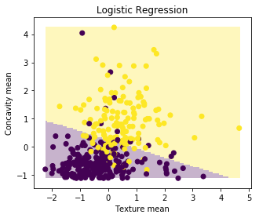

```python
plt.scatter(X1, X2, c=Y)
plt.xlabel("Texture mean")
plt.ylabel("Concavity mean")
plt.title("Logistic Regression")
plt.show()
```

4: How does the result for kNN compare to that for Logistic Regression?

Logistic Regression seems to do a pretty good job at deciding the decision boundary between these two variables. kNN seems to pick up noise a little better than Logistic Regression. We can see this in the later values for Texture mean. Of course, this is ignoring training/testing/overfitting issues for now.